# An Investigation of Key Determinants of U.S. GDP Growth: A Keynesian-Inspired Approach

Kaleb Jordan

2025-01-14

## **Abstract**

[interactive chart not shown]

## **Introduction**

Economic growth is one of the most fundamental objectives for policymakers, economists, and institutions around the world. To enhance the effectiveness monetary policies, it is critical to understand the underlying factors that drive economic growth, more specifically: **GDP Growth**. For over a century, the Keynesian economic framework has provided a solid foundation for understanding aggregate demand and its components, notably consumption, investment, government spending, and net exports. In this study, I drew inspiration from the Keynesian model to create a modern approach and investigate the relationship between GDP growth and these key determinants, utilizing a combination of theoretical insight and empirical modeling techniques.

Given the complexities of economic systems, I decided to use an elastic net model to model the relationships between the variables:

- **Elastic Net Model**: a linear regression model that combines two regularization techniques: **Lasso** (L1 regularization) and **Ridge** (L2 regularization).

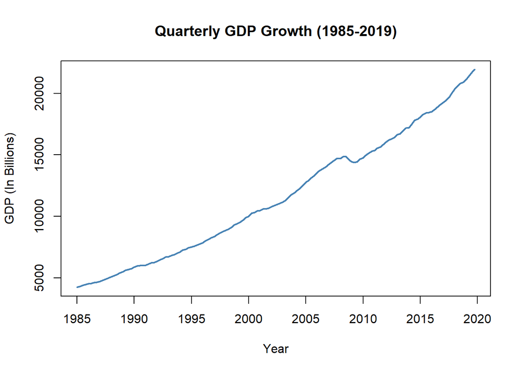

## **Theoretical Framework**

### **Keynesian Economic Theory**

Keynesian economic theory emphasizes the role of aggregate demand in determining the overall level of economic activity. GDP is the sum of consumption (C), investment (I), government spending (G), and net exports (X-M). Where:

- **Consumption (C)**: Driven by consumer sentiment and household income, consumption is often the largest component of GDP.
- **Investment (I)**: Reflects business sentiment and the amount of credit available to firms, with potential lag effects on the economy.
- **Government Spending (G)**: Comprising public expenditures aimed at stimulating demand through fiscal policies, such as infrastructure investments.
- **Net Exports (X-M)**: Representing the trade balance, this component reflects external demand for domestic goods and services.

[interactive chart not shown]

### **Keynesian Dynamics**

These components interact within a dynamic system affected by external forces, such as changes in government policy, interest rates, or global economic conditions. The role of these exogenous factors has often been a subject of debate, especially when we consider how external variables influence these domestic economic components.

1. **Government Expenditures (G)** can directly determine demand into the economy through stimulus packages or public services.
2. **Interest Rates** can influence **Investment (I)** by altering borrowing costs.
3. **Sentiment** (such as **Consumer Sentiment** and **Business Sentiment**) provide information on the willingness of households and firms to spend or invest, influencing **C** and **I**.
4. **Net Exports (X-M)** are impacted by exchange rates, trade policies, and global demand for domestic goods and services.

While the basic Keynesian model treats these relationships as linear and static, modern data-driven methods allow for more flexibility in modeling potentially complex dynamics.

## **Data Description**

This study uses quarterly U.S. data from 1985 to 2020, gathered from Federal Reserve Bank of St. Louis. The data set consists of:

1. **GDP (In Billions):** The target variable representing the U.S. Gross Domestic Product. The total monetary or market value of all goods and services produced within a country’s economy, measured in billions. It serves as a broad indicator of a nation’s economic health.
2. **Consumer Sentiment:** A statistical measurement that indicates the overall attitude of consumers toward the economy. It reflects consumer confidence, considering factors like their views on personal finances, business conditions, and employment expectations.
3. **Federal Funds Effective Rate:** The interest rate at which institutions lend reserve balances to other depository institutions overnight on an uncollateralized basis.
4. **Total Credit to Private Non-Financial Sector:** Refers to the total credit provided to the private sector, excluding financial institutions, by banks and other lenders.
5. **Capacity Utilization:** The percentage of potential economic output that is actually being produced. Higher levels of utilization indicate the economy is closer to full capacity and economic activity is high.
6. **Government Expenditures:** The total amount of money spent by the government on goods and services, including public services, infrastructure, defense, healthcare, education, and social security programs.
7. **Net Exports:** The difference between a country’s exports and imports of goods and services. A positive value (exports greater than imports) signifies a trade surplus, and a negative value signifies a trade deficit.
8. **Government Balance:** The difference between government revenues (mostly from taxes) and expenditures. A positive balance indicates a surplus, while a negative balance indicates a deficit.
9. **Population:** The total number of people living in a particular region or country. Key variable for understanding economic factors like consumer demand and labor force size.
10. **Housing Price Index:** An index that measures the price changes of residential properties over time. It indicates how housing market values are changing and affects economic stability and wealth perception.
11. **Disposable Income:** The amount of income left for an individual or household after taxes, typically available for spending or saving. It serves as an indicator of consumer financial health.
12. **Unemployment Rate:** The percentage of the labor force that is unemployed and actively seeking employment. It is a key indicator of economic stability and job market conditions.
13. **Corporate Profits:** The total profits of businesses within a given economy, reflecting business health and the economy’s overall financial performance. High corporate profits often suggest good economic conditions and potential for reinvestment.

The time series data are structured on a quarterly basis, ensuring consistency for time series modeling. All data were cleaned, transformed to a uniform time frequency, and merged into a single data set.

## **Methodology**

### **Elastic Net Model**

**Elastic Net Regression** was integrated to model the relationship between the response variable and a series of predictors. This technique is particularly suited for data sets with a large number of predictors, potential multicollinearity among variables, or when variable selection is desired. The **Elastic Net** combines the penalties of **Lasso** (L1) and **Ridge** (L2) regression, enabling both feature selection and coefficient regularization.

#### Key Aspects of Elastic Net Regression:

1. **Model Specification**: The Elastic Net minimizes a loss function comprising the residual sum of squares and a penalty term that includes a mixture of L1 and L2 norms. This penalty term is controlled by two hyper-parameters:
   - **Lambda**: Controls the overall regularization strength, with larger values increasing shrinkage.
   - **Alpha**: Governs the trade-off between L1 (Lasso) and L2 (Ridge) penalties. Alpha=1 results in Lasso regression, while alpha=0 corresponds to Ridge regression. A value of 0 < alpha < 1 blends the two.
2. **Regularization**:
   - The L1 penalty encourages sparsity in the coefficients, potentially setting some coefficients to zero and facilitating variable selection.
   - The L2 penalty shrinks the magnitude of coefficients, addressing multicollinearity by distributing weight across correlated predictors.
3. **Hyperparameter Tuning**:
   - Cross-validation was utilized to identify the optimal combination of lambda and alpha. This ensures that the model generalizes well to unseen data and avoids overfitting.

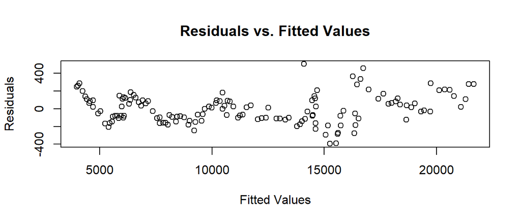

### **Elastic Net Model Results**

The Elastic Net regression model was employed to analyze the relationship between various predictors and the target variable, GDP (in billions). The results of the model are summarized as follows:

1. **Optimal Lambda Value**:  
   The model selected the optimal regularization parameter, lambda, as **23.78592**. This parameter strikes a balance between the L1 (lasso) and L2 (ridge) penalties, allowing for both feature selection and reduced collinearity among predictors.
2. **Root Mean Squared Error (RMSE)**:  
   The model’s RMSE on the full data set was **159.45**, indicating the average deviation of the predicted GDP values from the actual values. Given the scale of the GDP (in billions), this error suggests a high degree of accuracy.
3. **Mean Absolute Percentage Error (MAPE)**:

   The model’s MAPE on the full data set was **1.32%**, representing the average magnitude of errors between the predicted and actual GDP values. Given the GDP scale (in billions), this error indicates a high level of accuracy in the model’s predictions.

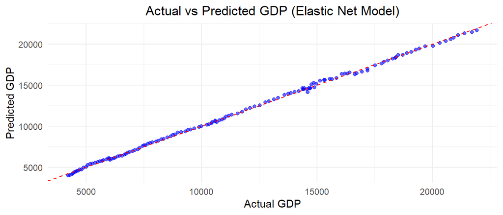

## Sources

**Gross Domestic Product (GDP)**  
Federal Reserve Bank of St. Louis. (2024). *Gross Domestic Product (GDP)* [Dataset]. FRED. Retrieved from https://fred.stlouisfed.org/series/GDP

**Consumer Sentiment**  
University of Michigan. (2024). *Index of Consumer Sentiment* [Dataset]. University of Michigan Surveys of Consumers. Retrieved from https://fred.stlouisfed.org/series/UMCSENT

**Federal Funds Effective Rate**  
Federal Reserve Bank of St. Louis. (2024). *Federal Funds Effective Rate* [Dataset]. FRED. Retrieved from https://fred.stlouisfed.org/series/FEDFUNDS

**Total Credit to Private Non-Financial Sector**  
Bank for International Settlements. (2024). *Total Credit to Private Non-Financial Sector* [Dataset]. BIS Statistics Explorer. Retrieved from https://fred.stlouisfed.org/series/QUSPAM770A

**Government Expenditures**  
Federal Reserve Bank of St. Louis. (2024). *Government Consumption Expenditures and Gross Investment* [Dataset]. FRED. Retrieved from https://fred.stlouisfed.org/series/GEXPND

**Government Balance**  
International Monetary Fund. (2024). *Government Net Lending/Borrowing* [Dataset]. IMF DataMapper. Retrieved from https://fred.stlouisfed.org/series/FGLBAFQ027S

**Median Weekly Income**  
U.S. Bureau of Labor Statistics. (2024). *Median Weekly Earnings of Full-Time Wage and Salary Workers* [Dataset]. Retrieved from https://fred.stlouisfed.org/series/LES1252881600Q

**Population**  
U.S. Census Bureau. (2024). *Total U.S. Population* [Dataset]. Retrieved from https://fred.stlouisfed.org/series/POPTHM

**Housing Price Index**  
Federal Housing Finance Agency. (2024). *FHFA House Price Index* [Dataset]. Retrieved from https://fred.stlouisfed.org/series/USSTHPI

**Disposable Income**  
Federal Reserve Bank of St. Louis. (2024). *Real Disposable Personal Income* [Dataset]. FRED. Retrieved from https://fred.stlouisfed.org/series/DPI

**Unemployment Rate**  
U.S. Bureau of Labor Statistics. (2024). *Unemployment Rate* [Dataset]. Retrieved from https://fred.stlouisfed.org/series/UNRATE

**Net Exports**  
Federal Reserve Bank of St. Louis. (2024). *Net Exports of Goods and Services* [Dataset]. FRED. Retrieved from https://fred.stlouisfed.org/series/NETEXP

**Capacity Utilization**  
Federal Reserve Bank of St. Louis. (2024). *Capacity Utilization: Total Industry* [Dataset]. FRED. Retrieved from https://fred.stlouisfed.org/series/TCU

**Corporate Profits**  
U.S. Bureau of Economic Analysis. (2024). *Corporate Profits After Tax with Inventory Valuation and Capital Consumption Adjustments* [Dataset]. BEA. Retrieved from https://fred.stlouisfed.org/series/CP